# Análisis de factores que influyen en el índice de democracia

Curso: POL304 - Estadística para el análisis político 2

Claudia Cabrel y Aisha Martínez

2022-11-04

## Introducción

La siguiente investigación analiza los factores que pueden perjudicar el índice de democracia a nivel mundial. Durante el desarrollo de esta investigación se ha identificado que existen diversos factores que influencian en el índice de democracia; sin embargo, se han elegido seis, los cuales se considera que son los de mayor importancia. En primer lugar, se presentarán factores políticos, representados a través del índice de la percepción de la corrupción, y el índice de paridad política. En segundo lugar, se agregarán factores económicos representados a través de la tasa de crecimeinto de PBI, el índice de libertad económica y el coeficiente de GINI. Por último, se utilizarán los países con educación secundaria pero sin educación terciaria como indicador del factor educación. Por tal motivo, se buscará poner a prueba si la hipótesis presentada (estos factores afectan negativamente el índice de democracia a nivel mundial) es certera.

## 1. Análisis rápido de la data

Al visualizar la data sin haber realizado ningún análisis estadístico, se observa que países con un mayor índice de libertad económica presentan de igual manera un relativamente mayor puntaje en el índice de democracia como se presenta por ejemplo en países como el Reino Unido, Suecia y Suiza. Sin embargo, no necesariamente sucede lo mismo en el caso del índice de paridad política y su efecto en el nivel de democracia, pues, así algunos países tengan un alto nivel de paridad política en su gestión, como por ejemplo: Rwanda, Argentina y Emiratos Árabes, no cuentan con un alto nivel de democracia. El mismo caso se da con la tasa de crecimiento de PBI, el coeficiente de GINI y los países con nivel de educación secundaria pero no terciaria. Es por tal motivo que se procederá a realizar un análisis de regresión lineal para luego proceder con una comparación de los modelos con el fin de observar qué variables tienen un mayor impacto positivo en el nivel de democracia a nivel mundial y así poner a prueba y obtener resultados respaldados estadísticamente de lo recién evaluado a primera vista.

## 2. Modelación

En este caso, se hará una regresión lineal múltiple con tres primeras variables, las cuales serán el índice de libertad económica, la tasa de crecimiento de PBI y el puntaje de los países en su índice de paridad política.

```
##
## Call:
## lm(formula = scoredemo ~ scorelibeco + scoreparpol + scorepbi,
##     data = data)
##
## Residuals:
##     Min      1Q  Median      3Q     Max
## -5.2287 -0.7561  0.2337  0.8490  3.1428
##
## Coefficients:
##              Estimate Std. Error t value Pr(>|t|)
## (Intercept) -3.741917   0.769855  -4.861 3.55e-06 ***
## scorelibeco  0.155298   0.012536  12.388  < 2e-16 ***
## scoreparpol  0.006409   0.011031   0.581   0.5623
## scorepbi    -0.063844   0.029450  -2.168   0.0321 *
## ---
## Signif. codes:  0 '***' 0.001 '**' 0.01 '*' 0.05 '.' 0.1 ' ' 1
##
## Residual standard error: 1.38 on 121 degrees of freedom
## Multiple R-squared:  0.5892, Adjusted R-squared:  0.579
## F-statistic: 57.84 on 3 and 121 DF,  p-value: < 2.2e-16
```

$$\operatorname{\widehat{scoredemo}} = -3.74 +
0.16(\operatorname{scorelibeco}) + 0.01(\operatorname{scoreparpol}) -
0.06(\operatorname{scorepbi})$$

Resumen de Regresion Lineal

|  | Model 1 |
| --- | --- |
| (Intercept) | -3.742*** |
|  | (0.770) |
| scorelibeco | 0.155*** |
|  | (0.013) |
| scoreparpol | 0.006 |
|  | (0.011) |
| scorepbi | -0.064* |
|  | (0.029) |
| Num.Obs. | 125 |
| R2 | 0.589 |
| R2 Adj. | 0.579 |
| AIC | 441.1 |
| BIC | 455.3 |
| Log.Lik. | -215.560 |
| F | 57.842 |
| RMSE | 1.36 |

+ p < 0.1, * p < 0.05, ** p < 0.01, *** p < 0.001

- Como resultado se observa que la variable con mayor impacto en el índice de democracia es la de libertad económica.

En cuanto al Coeficiente de Determinación también conocido como R2, este nos ayudará a interpretar el porcentaje de variabilidad total de la variable dependiente que es explicada por la variable independiente. Estos valores pueden ir del 0 al 1, si el caso del R2 se encuentra más cercano a 1, mayor será la variabilidad explicada, ayudando a indicar el ajuste del modelo.

Por ende, si bien la variable más significativa en Modelo 1 seria libertad económica, por ende, a mayor libertad económica, mayor democracia.

- Por otra parte, se hará una regresión lineal múltiple con las otras tres variables, las cuales serán el índice de percepción de corrupción, los países con educación secundaria pero no terciaria y el coeficiente de GINI.

```
##
## Call:
## lm(formula = scoredemo ~ cpiscore + educasec + gini_ind, data = data)
##
## Residuals:
##     Min      1Q  Median      3Q     Max
## -4.9722 -0.8189  0.2966  1.1058  2.0237
##
## Coefficients: (1 not defined because of singularities)
##             Estimate Std. Error t value Pr(>|t|)
## (Intercept) 1.317452   0.900242   1.463    0.146
## cpiscore    0.084453   0.007466  11.312   <2e-16 ***
## educasec    0.016231   0.018481   0.878    0.382
## gini_ind          NA         NA      NA       NA
## ---
## Signif. codes:  0 '***' 0.001 '**' 0.01 '*' 0.05 '.' 0.1 ' ' 1
##
## Residual standard error: 1.461 on 122 degrees of freedom
## Multiple R-squared:  0.5354, Adjusted R-squared:  0.5277
## F-statistic: 70.29 on 2 and 122 DF,  p-value: < 2.2e-16
```

$$\operatorname{\widehat{scoredemo}} = 1.32 +
0.08(\operatorname{cpiscore}) + 0.02(\operatorname{educasec}) +
NA(\operatorname{gini\_ind})$$

Resumen de Regresion Lineal 2

|  | Model 1 |
| --- | --- |
| (Intercept) | 1.317 |
|  | (0.900) |
| cpiscore | 0.084*** |
|  | (0.007) |
| educasec | 0.016 |
|  | (0.018) |
| Num.Obs. | 125 |
| R2 | 0.535 |
| R2 Adj. | 0.528 |
| AIC | 454.5 |
| BIC | 465.8 |
| Log.Lik. | -223.252 |
| RMSE | 1.44 |

+ p < 0.1, * p < 0.05, ** p < 0.01, *** p < 0.001

- Como resultado se observa que la variable con mayor impacto en el índice de democracia es la de la percepción de corrupción.

En el Modelo 2, la variable más significativa seria la percepción de corrupción, por ende, a mayor percepción de corrupción, mayor democracia.

En esta sección, se realizará una comparación de ambos modelos:

[output not shown]

[output not shown]

```
##
## ===================================================================
##                                   Dependent variable:
##                     -----------------------------------------------
##                                        scoredemo
##                               (1)                     (2)
## -------------------------------------------------------------------
## scorelibeco                0.155***
##                             (0.013)
##
## scoreparpol                  0.006
##                             (0.011)
##
## scorepbi                   -0.064**
##                             (0.029)
##
## cpiscore                                           0.084***
##                                                     (0.007)
##
## educasec                                             0.016
##                                                     (0.018)
##
## gini_ind
##
##
## Constant                   -3.742***                 1.317
##                             (0.770)                 (0.900)
##
## -------------------------------------------------------------------
## Observations                  125                     125
## R2                           0.589                   0.535
## Adjusted R2                  0.579                   0.528
## Residual Std. Error    1.380 (df = 121)        1.461 (df = 122)
## F Statistic         57.842*** (df = 3; 121) 70.285*** (df = 2; 122)
## ===================================================================
## Note:                                   *p<0.1; **p<0.05; ***p<0.01
```

- Se observa, en los resultados obtenidos al comparar ambos modelos, que existe una fuerza en la relación entre el modelo y la variable dependiente debido a que la diferencia entre las observaciones y los valores pronosticados son pequeñas. De igual forma, el R2 nos indica que el porcentaje de la varianza en la variable dependiente que las variables independientes explican colectivamente ha obtenido un valor mayor al 50%, por ende, nos presenta que el modelo explica en mayor medida la variabilidad de los datos en torno a su media. Sin embargo, el R2 ajustado nos demustra que al haberse obtenido un valor menor a 1 no hay valores predictivos en los modelos.

Por útlimo, se realizará un tercer modelo en el que uniremos las seis variables para observar si es que los resultados cambian, si es que hay más variables con mayor impacto en el nivel de democracia o si es que se da el caso contrario.

```
##
## Call:
## lm(formula = scoredemo ~ cpiscore + educasec + gini_ind + scorelibeco +
##     scoreparpol + scorepbi, data = data)
##
## Residuals:
##     Min      1Q  Median      3Q     Max
## -5.1543 -0.6311  0.3462  0.8084  2.8297
##
## Coefficients: (1 not defined because of singularities)
##              Estimate Std. Error t value Pr(>|t|)
## (Intercept) -3.048832   1.264190  -2.412  0.01741 *
## cpiscore     0.035845   0.012226   2.932  0.00404 **
## educasec     0.019500   0.017119   1.139  0.25696
## gini_ind           NA         NA      NA       NA
## scorelibeco  0.107699   0.021446   5.022 1.82e-06 ***
## scoreparpol -0.001425   0.011078  -0.129  0.89789
## scorepbi    -0.043704   0.029422  -1.485  0.14007
## ---
## Signif. codes:  0 '***' 0.001 '**' 0.01 '*' 0.05 '.' 0.1 ' ' 1
##
## Residual standard error: 1.341 on 119 degrees of freedom
## Multiple R-squared:  0.618,  Adjusted R-squared:  0.602
## F-statistic: 38.51 on 5 and 119 DF,  p-value: < 2.2e-16
```

$$\operatorname{\widehat{scoredemo}} = -3.05 +
0.04(\operatorname{cpiscore}) + 0.02(\operatorname{educasec}) +
NA(\operatorname{gini\_ind}) + 0.11(\operatorname{scorelibeco}) +
0(\operatorname{scoreparpol}) - 0.04(\operatorname{scorepbi})$$

Resumen de Regresion Lineal

|  | Model 1 |
| --- | --- |
| (Intercept) | -3.049* |
|  | (1.264) |
| cpiscore | 0.036** |
|  | (0.012) |
| educasec | 0.020 |
|  | (0.017) |
| scorelibeco | 0.108*** |
|  | (0.021) |
| scoreparpol | -0.001 |
|  | (0.011) |
| scorepbi | -0.044 |
|  | (0.029) |
| Num.Obs. | 125 |
| R2 | 0.618 |
| R2 Adj. | 0.602 |
| AIC | 436.0 |
| BIC | 455.8 |
| Log.Lik. | -211.007 |
| RMSE | 1.31 |

+ p < 0.1, * p < 0.05, ** p < 0.01, *** p < 0.001

En este último Modelo 3, la variable más significativa seria la libertad económica frente a todas las dempás variables vistas en el Modelo 1 y el Modelo 2.

## 3. Análisis factorial

Mediante este análisis factorial exploratorio podremos explorar la data y se nos entregará los posibles factores que resúmen cada uno un conjunto de variables.

A continuación, se subseteará la data:

En el siguiente paso se realizará el cálculo de la matriz de correlación:

La figura mostrada a continuación nos muestra las correlaciones entre algunas de las variables utilizadas:

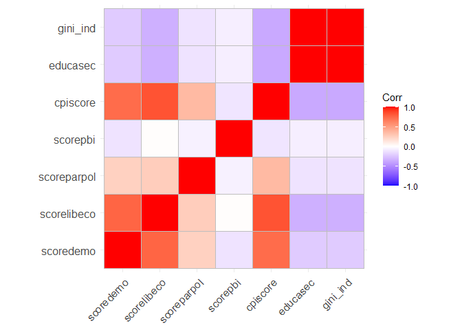

Se observa que las variables de libertad económica y de percepción de la corrupción tienen mayor correlación con la variable dependiente del índice de democracia; sin embargo, el índice de paridad política también presenta cierto nivel de correlación, ´pero menor que las recién mencionadas.

En el siguiente paso se verificará si los datos permiten factorizar

[output not shown]

```
## matrix is not invertible, image not found
```

```
## Kaiser-Meyer-Olkin factor adequacy
## Call: psych::KMO(r = corMatrix)
## Overall MSA =  0.5
## MSA for each item =
##   scoredemo scorelibeco scoreparpol    scorepbi    cpiscore    educasec
##         0.5         0.5         0.5         0.5         0.5         0.5
##    gini_ind
##         0.5
```

Seguidamente, se verificará si la matriz de correlación es adecuada. Para ello se realizarán dos pruebas:

Hnula: La matriz de correlacion es una matriz identidad

```
## [1] FALSE
```

Hnula: La matriz de correlacion es una matriz singular.

```
## [1] TRUE
```

- Entonces, se presenta como resultado que la matriz de correlación es una matriz singular, lo cual indica que su determinante es cero y que sus filas o columnas están proporcionalmente interrelacionadas.

Luego se buscará determinar en cuantos factores o variables latentes podríamos redimensionar la data, para ello utilizaremos la función fa.parallel:

[output not shown]

```
## In factor.scores, the correlation matrix is singular, the pseudo inverse is  used
```

```
## I was unable to calculate the factor score weights, factor loadings used instead
```

```
## Parallel analysis suggests that the number of factors =  2  and the number of components =  NA
```

- Se obtuvo como resultado que la recomendación es redimensionar la data en 2 factores.

A continuación, se redimensionará a un número menor de factores

Resultado inicial:

[output not shown]

```
## In factor.scores, the correlation matrix is singular, the pseudo inverse is  used
```

```
## I was unable to calculate the factor score weights, factor loadings used instead
```

```
##
## Loadings:
##             MR1    MR2
## scoredemo    0.818
## scorelibeco  0.882 -0.160
## scoreparpol  0.326
## scorepbi           -0.100
## cpiscore     0.911 -0.174
## educasec    -0.218  0.974
## gini_ind    -0.218  0.974
##
##                  MR1   MR2
## SS loadings    2.488 1.969
## Proportion Var 0.355 0.281
## Cumulative Var 0.355 0.637
```

Resultado mejorado:

```
##
## Loadings:
##             MR1    MR2
## scoredemo    0.818
## scorelibeco  0.882
## scoreparpol
## scorepbi
## cpiscore     0.911
## educasec            0.974
## gini_ind            0.974
##
##                  MR1   MR2
## SS loadings    2.488 1.969
## Proportion Var 0.355 0.281
## Cumulative Var 0.355 0.637
```

Resultado visual: El resultado lo podemos ver de manera gráfica en la figura a continuación:

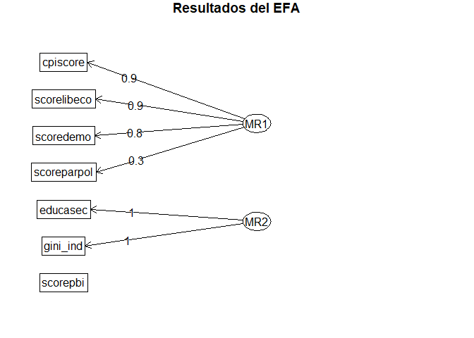

Habiendo evaluando los resultados obtenidos procederemos con la siguiente evaluación para responder a la pregunta: ¿Qué variables aportaron más a los factores?

```
##    scorepbi scoreparpol   scoredemo scorelibeco    cpiscore    educasec
##  0.02004262  0.10817881  0.67084211  0.80302001  0.86087687  0.99720350
##    gini_ind
##  0.99720350
```

¿Qué variables contribuyen a más de un factor?

```
##   scoredemo scoreparpol scorelibeco    cpiscore    educasec    gini_ind
##    1.004610    1.039842    1.065957    1.072687    1.099918    1.099918
##    scorepbi
##    1.999880
```

Valores proyectados: Podemos calcular dos indices que resuman los dos factores encontrados.

```
##          MR1        MR2
## 1  0.3219213 -1.3321592
## 2 -2.1978246 -2.3210328
## 3 -3.2395202  3.4834007
## 4 -0.8075282  0.8893327
## 5  0.1651141 -1.3016353
## 6  4.2623863 -1.5025641
```

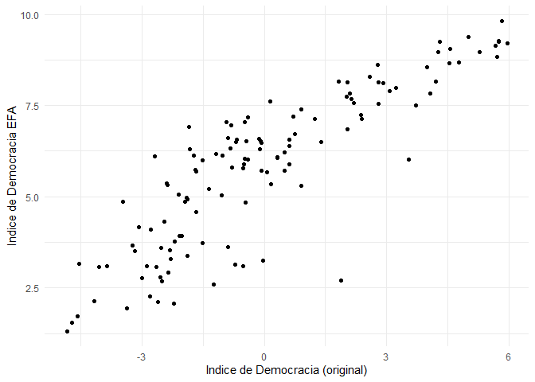

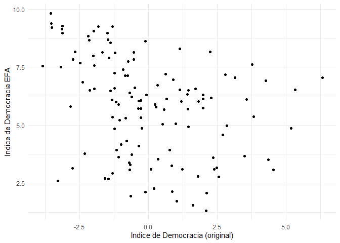

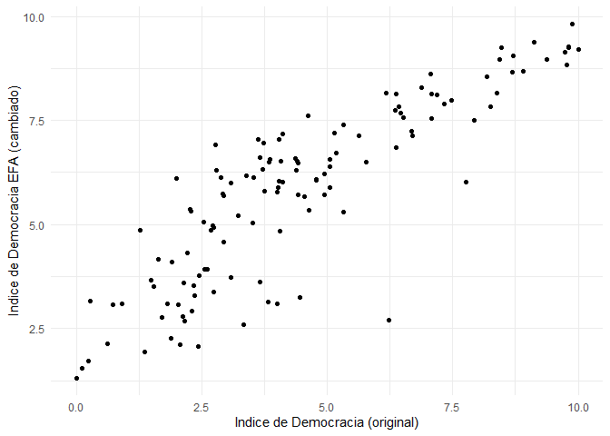

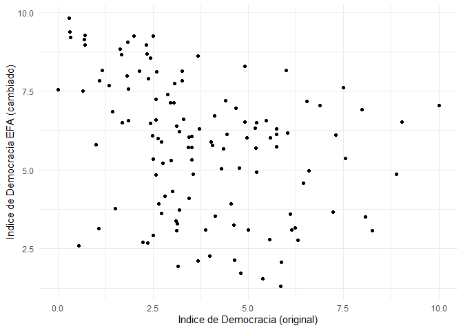

## Análisis de cluster

- No podemos usar la columna ‘country’ en la clusterización, pero tampoco debemos perderla, por lo que se recomienda usar esos nombres en lugar del nombre de fila.
- Ya con los datos en el objeto dataClus, calculemos la matriz de distancias entre los casos (paises):

# Proceso de clusterización

## Para realizar el proceso de clusterización se hará uso de la Estrategia Jerárquica - divisiva

Primero, se decidirá la cantidad de cluster a utilizar mediante una solicitud usando el estadístico ‘gap’

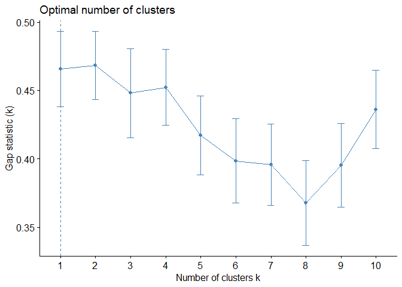

## Clusterizar vía DIANA

|  | scoredemo | scorelibeco | scoreparpol | scorepbi | cpiscore | educasec | gini_ind | diana |
| --- | --- | --- | --- | --- | --- | --- | --- | --- |
| Albania | 6.08 | 4.782365 | 29.5 | 6.067882 | 2.4797461 | 33.2 | 33.2 | 1 |
| Algeria | 3.77 | 2.450811 | 25.8 | 4.438258 | 1.5070187 | 27.6 | 27.6 | 1 |
| Angola | 3.66 | 1.486916 | 30.0 | 11.031830 | 7.2166782 | 51.3 | 51.3 | 2 |
| Argentina | 6.95 | 3.737270 | 40.9 | 7.729489 | 4.6649658 | 41.4 | 41.4 | 2 |
| Armenia | 5.35 | 4.637269 | 23.5 | 14.643208 | 2.5097716 | 34.4 | 34.4 | 1 |
| Australia | 8.96 | 8.428529 | 30.0 | 1.807784 | 2.3121235 | 34.4 | 34.4 | 1 |
| Austria | 8.16 | 8.371925 | 39.3 | 1.549877 | 1.1682493 | 29.7 | 29.7 | 1 |
| Azerbaijan | 2.68 | 2.161434 | 17.4 | 26.660095 | 2.3533335 | 33.7 | 33.7 | 1 |
| Bangladesh | 5.99 | 3.086723 | 20.9 | 4.965841 | 2.6349309 | 32.4 | 32.4 | 1 |
| Belarus | 2.59 | 3.329148 | 40.0 | 10.149767 | 0.5542816 | 25.2 | 25.2 | 1 |
| Belgium | 7.51 | 7.930101 | 41.3 | 1.760456 | 0.6638767 | 27.4 | 27.4 | 1 |
| Benin | 4.58 | 2.927485 | 7.2 | -1.245890 | 6.4511533 | 47.8 | 47.8 | 2 |
| Bhutan | 5.71 | 4.951297 | 14.9 | 5.644230 | 3.4207075 | 37.4 | 37.4 | 1 |
| Bosnia and Herzegovina | 4.84 | 4.059652 | 26.2 | 3.865777 | 2.5657068 | 33.0 | 33.0 | 1 |
| Botswana | 7.62 | 4.610153 | 10.8 | 2.607175 | 7.4957339 | 53.3 | 53.3 | 2 |

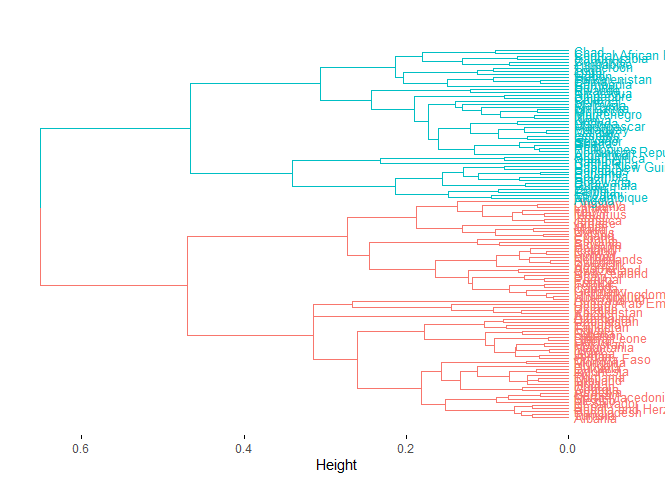

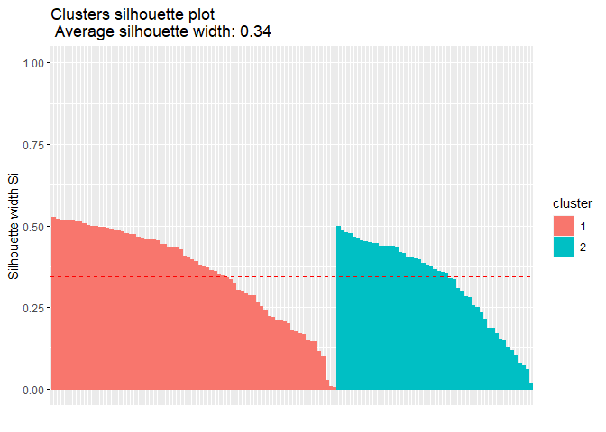

* Nótese que no se presentan valores mal clusterizados; por ende, no habrá necesidad de evaluar los resultados.

## Verificando Etiqueta

- A continuación, exploraremos el promedio de cada cluster.

```
##   diana scoredemo scorelibeco scoreparpol scorepbi cpiscore educasec gini_ind
## 1     1  6.370405    5.531140    27.39054 4.087965 2.375102 33.11757 33.11757
## 2     2  4.961765    2.965813    24.88431 3.148474 5.843367 45.63922 45.63922
```

- No se observa un orden, por lo tanto se reordenará.

```
##   diana scoredemo scorelibeco scoreparpol scorepbi cpiscore educasec gini_ind
## 2     2  4.961765    2.965813    24.88431 3.148474 5.843367 45.63922 45.63922
## 1     1  6.370405    5.531140    27.39054 4.087965 2.375102 33.11757 33.11757
```

Esas posiciones hay que usarlas para recodificar:

Guardemos la columna de DIANA en la data integrada, y eliminemosla de dataClus.

# Visualización comparativa

Vamos a usar la matriz de distancia para darle a cada país una coordenada, tal que la distancia entre esos paises se refleje en sus posiciones. Eso requiere una técnica que proyecte las dimensiones originales en un plano bidimensional. Para ello usaremos la técnica llamada escalamiento multidimensional. Veamos algunas coordenadas.

```
##                               [,1]        [,2]
## Albania                -0.13449478  0.06374688
## Algeria                -0.08200583  0.25795853
## Angola                  0.39186594 -0.04890302
## Argentina               0.06032366 -0.12662269
## Armenia                -0.07726082  0.14300864
## Australia              -0.30379663 -0.08775832
## Austria                -0.38935648 -0.09178622
## Azerbaijan              0.04125959  0.37856451
## Bangladesh             -0.06500966  0.13170436
## Belarus                -0.14179337  0.26878629
## Belgium                -0.39032676 -0.07829680
## Benin                   0.34268792 -0.06186938
## Bhutan                  0.00192567  0.05869913
## Bosnia and Herzegovina -0.07313604  0.13675433
## Botswana                0.23474832 -0.32211105
## Brazil                  0.32038137 -0.25197746
## Bulgaria                0.01435017 -0.07020172
## Burkina Faso            0.05961703  0.22465408
## Burundi                 0.17484297  0.14872335
## Cambodia                0.16121993  0.24429507
```

Habiendo calculado la proyeccción, recuperemos las coordenadas del mapa del mundo basado en nuestras dimensiones nuevas:

[output not shown]

[output not shown]

[output cut: 46 more lines]

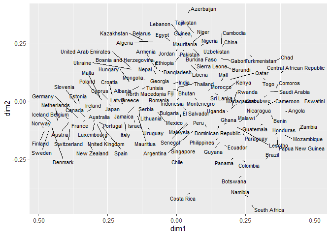